# R for beginners

### Bar plot with errorbars

```r
# let's create some data
mydata <- data.frame(group = c("A", "A", "A", "A", "A", "A", "B", "B", "B", "B", "B", "B"), Time = as.factor(c(1, 2, 1, 2, 1, 2, 1, 2, 1, 2,
    1, 2)), yval = c(11, 3, 5, 6, 9, 1, 2, 3, 4, 5, 1, 0))
mydata
```

```
##    group Time yval
## 1      A    1   11
## 2      A    2    3
## 3      A    1    5
## 4      A    2    6
## 5      A    1    9
## 6      A    2    1
## 7      B    1    2
## 8      B    2    3
## 9      B    1    4
## 10     B    2    5
## 11     B    1    1
## 12     B    2    0
```

The 1st way is to compute the SEs yourself (SD/sqrt(N)), and then plot them with `geom_errorbar`

```r
mydata_summary <- ddply(mydata, c("group", "Time"), summarise, M = mean(yval, na.rm = TRUE), SD = sd(yval, na.rm = TRUE), N = sum(!is.na(yval)),
    SE = SD/sqrt(N))
mydata_summary  # look at the computed parameters
```

```
##   group Time        M       SD N        SE
## 1     A    1 8.333333 3.055050 3 1.7638342
## 2     A    2 3.333333 2.516611 3 1.4529663
## 3     B    1 2.333333 1.527525 3 0.8819171
## 4     B    2 2.666667 2.516611 3 1.4529663
```

```r
library(ggplot2)  # load ggplot2, if necessary
errorbars1 <- ggplot(mydata_summary, aes(x = Time, y = M, fill = group)) + geom_bar(stat = "identity", position = position_dodge(0.5), width = 0.5) +
    geom_errorbar(aes(ymin = M - SE, ymax = M + SE), position = position_dodge(0.5), width = 0.2) + ggtitle("SEs by hand")
# position_dodge defines the spacing between bars (per default it is the same as the bar width, i.e. 0.9) position='dodge' is the short form
# of position=position_dodge()
```

The 2nd (easier) way is to have ggplot do it for you using `fun.data = mean_se`:

```r
errorbars2 <- ggplot(mydata, aes(x = Time, y = yval, fill = group)) + stat_summary(fun.y = "mean", geom = "bar", position = position_dodge(0.5),
    width = 0.5) + # the height of the bars represents the mean per Time and group
stat_summary(fun.data = mean_se, geom = "errorbar", position = position_dodge(0.5), width = 0.2) + # the errorbars show the SE
ggtitle("Automatic SEs")
```

We use the package cowplot (see [here](https://cran.r-project.org/web/packages/cowplot/vignettes/introduction.html)) to arrange the 2 plots next to each other, and label them with A and B.  
Using this package also makes the plots a bit nicer (white background, etc.)

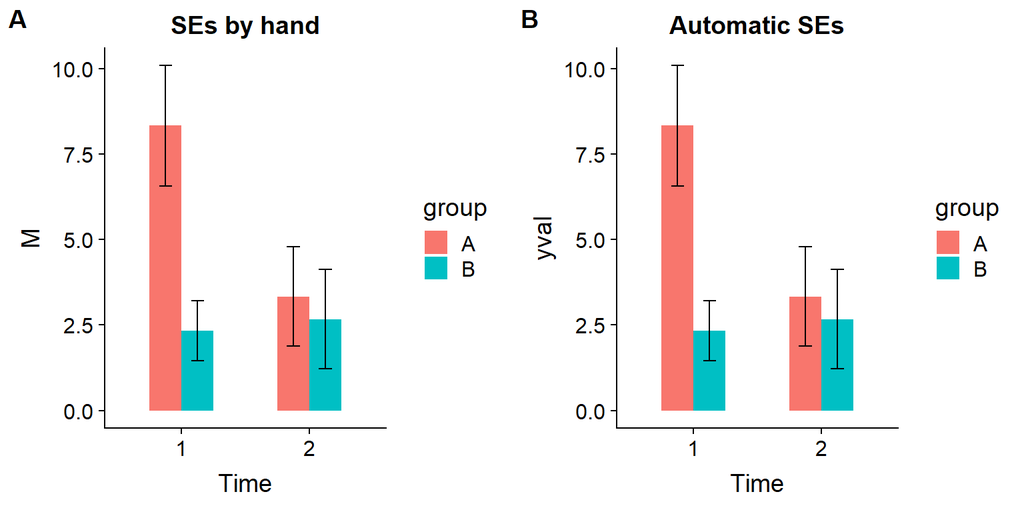

```r
####### if necessary install and/or load cowplot: install.packages('cowplot')
library(cowplot)
plot_grid(errorbars1, errorbars2, labels = c("A", "B"))
```

Reassuringly, the 2 graphs look exactly the same.

### Box plot with data points (grouped by 1 factor)

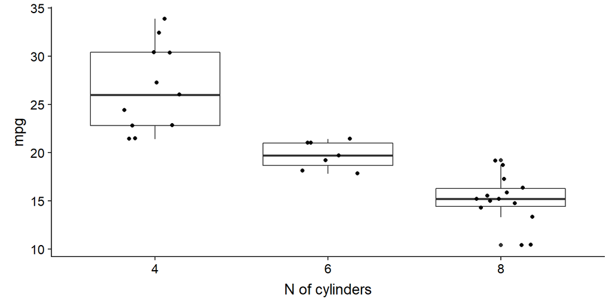

```r
# ATTENTION: for the x-axis you need a factor, or a vector of characters
ggplot(mtcars, aes(as.factor(cyl), mpg)) +
                  geom_boxplot() +
                  geom_jitter(width = 0.2) +  # we can move each data point a bit to the right or left, to make it visible
                  labs(x = "N of cylinders")
```

### Box plot with data points (grouped by 2 factors)

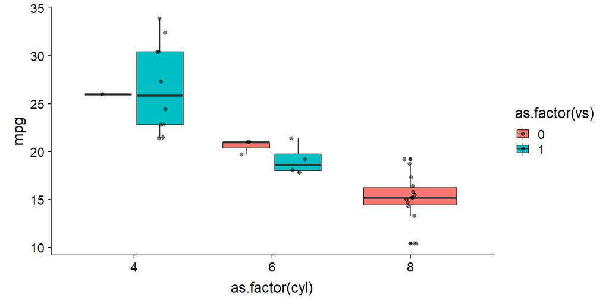

```r
# plot
ggplot(mtcars, aes(x = as.factor(cyl), y = mpg, fill = as.factor(vs))) + geom_boxplot() + geom_point(alpha = 0.5, position = position_jitterdodge(jitter.width = 0.2),
    aes(group = as.factor(vs)))
```

#### Violin plot

The better boxplot, as it also shows the distribution of the data (a kernel density plot).

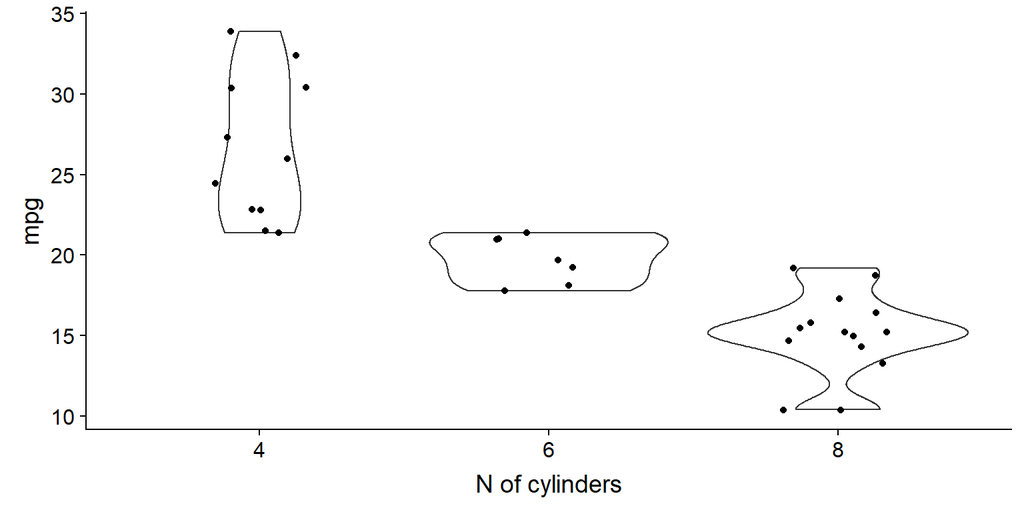

```r
# ATTENTION: for the x-axis you need a factor, or a vector of characters
ggplot(mtcars, aes(as.factor(cyl), mpg)) +
                  geom_violin() +
                  geom_jitter(width = 0.2) +  # we can move each data point a bit to the right or left, to make it visible
                  labs(x = "N of cylinders")
```

### Violin and box plots combined

We can overlay box plots and violin plots made with ggplot2. For that, we need to specify their positions using te function [`position_dodge`](https://ggplot2.tidyverse.org/reference/position_dodge.html)

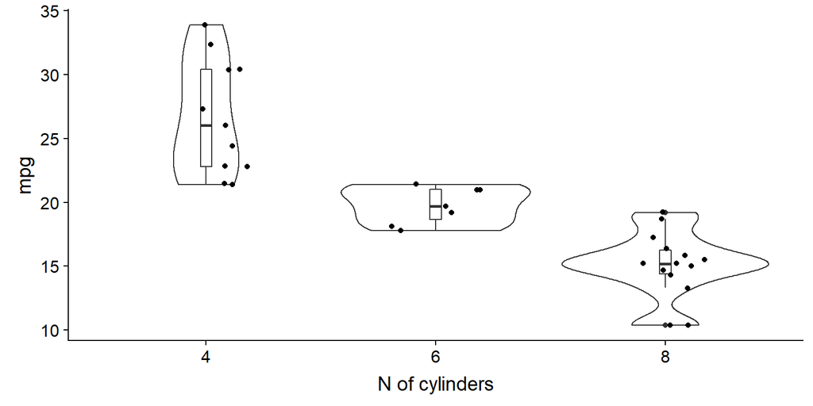

```r
ggplot(mtcars, aes(as.factor(cyl), mpg)) +
                  geom_violin(position = position_dodge(width = .04)) +
                  geom_boxplot(width = .05, position = position_dodge(width = .04)) +
                  geom_jitter(width = 0.2) +  # we can move each data point a bit to the right or left, to make it visible
                  labs(x = "N of cylinders")
```

## Pirate plots

The function `pirateplot` from the `yarrr` package allows to easily combine box plots, violin plots, and the representation of every single data point. There are many built-in color palettes you can choose from

```r
library("yarrr")
```

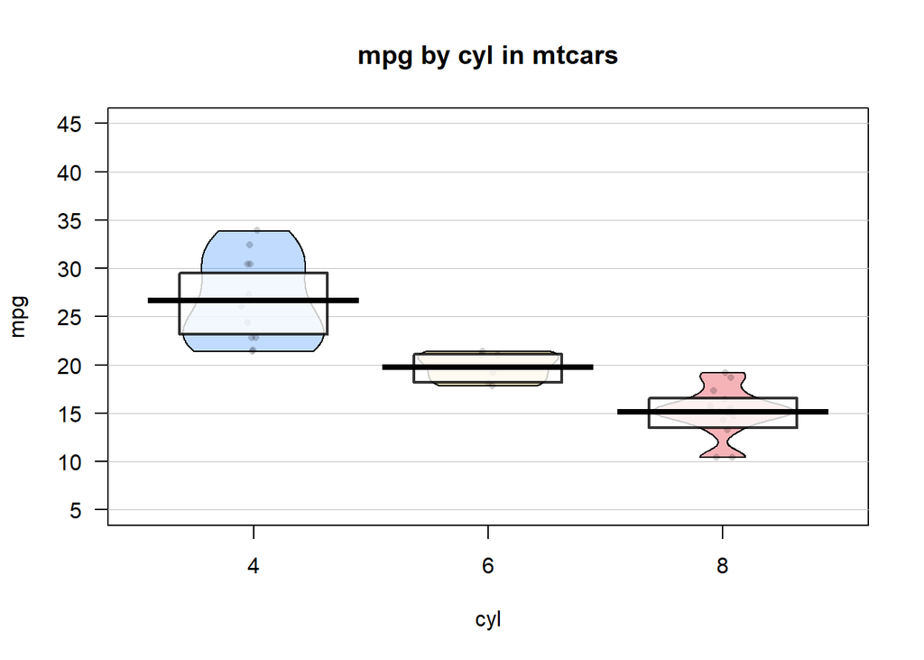

```r
pirateplot(formula = mpg ~ cyl, data = mtcars, pal = "southpark", main = "mpg by cyl in mtcars", ylim = c(5, 45))
```

You can have up to 3 different categorigal IVs for pirate plots

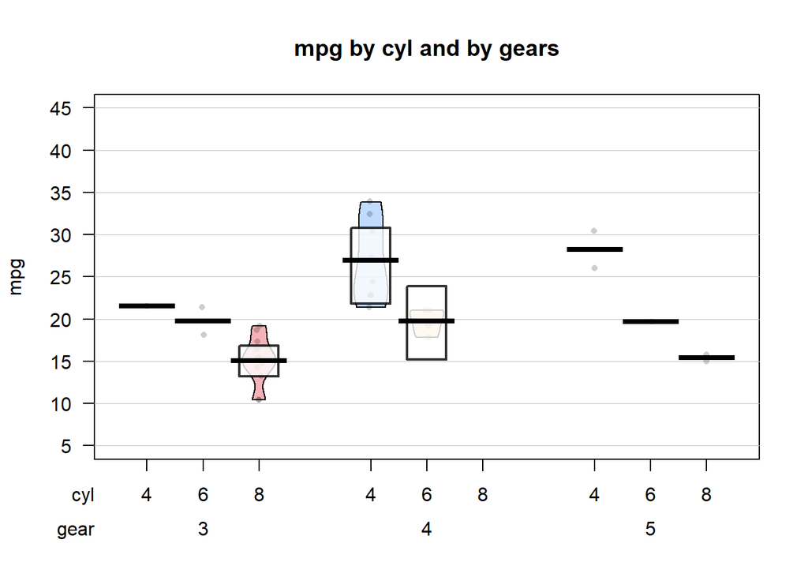

```r
pirateplot(formula = mpg ~ cyl + gear, data = mtcars, pal = "southpark", main = "mpg by cyl and by gears", ylim = c(5, 45))
```

But, as far as I know, you cannot assign a pirateplot to an object, as you can do with ggplot2. This means that it is difficult to arrange several pirate plots in the same figure (see below).

## Arranging several plots in a figure

If you plot with the base graphics package, you can put several plots in 1 figure using the `par` function But this does not work with graphs made with `ggplot2`, for which one can use the `cowplot`or `gridExtra`packages instead.

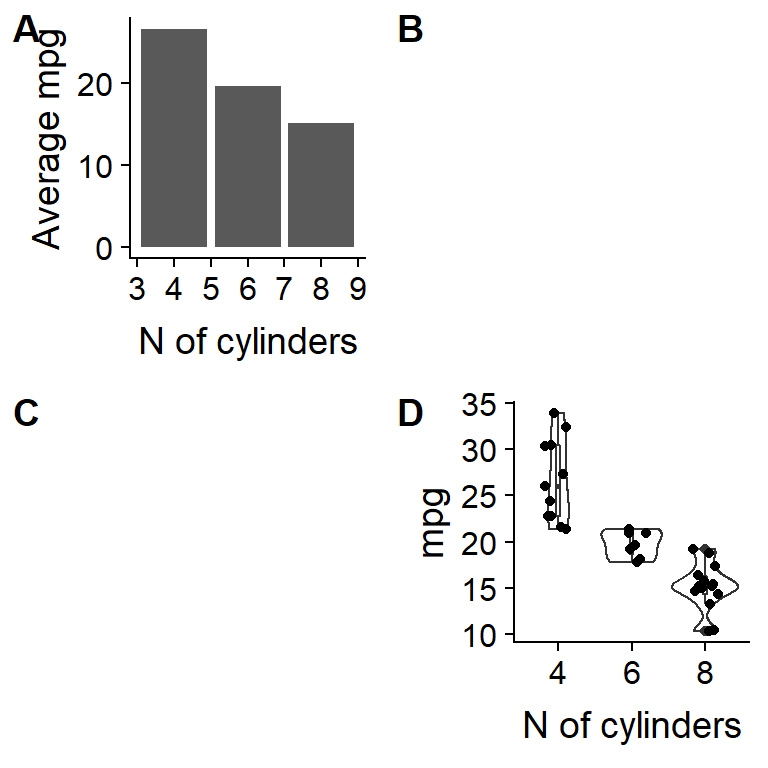

```r
library(cowplot)

plot1 <- ggplot(mtcars, aes(cyl, mpg)) +
                  geom_bar(stat="summary", fun.y = "mean") +
                  labs(x = "N of cylinders") +
                  labs(y = "Average mpg")
plot2 <- ggplot(mtcars, aes(as.factor(cyl), mpg)) +
                  geom_violin(position = position_dodge(width = .04)) +
                  geom_boxplot(width = .05, position = position_dodge(width = .04)) +
                  geom_jitter(width = 0.2) +  # we can move each data point a bit to the right or left, to make it visible
                  labs(x = "N of cylinders")
# let's put plot1 and plot2 together, but in positions 1 and 4 of a 4-plot scenario
plot_grid(plot1, NULL, NULL, plot2, labels = c("A", "B", "C", "D"), ncol = 2)
```

## Saving your plots and graphs

You can save your graphs by hand using the **Export** button on the right-hand **Plots** tab.  
Or you define in your script how and where to save a graph (see [link](https://www.stat.berkeley.edu/classes/s133/saving.html)).

Here, I save to .pdf, by first defining the name (with the path!),  
calling `pdf()` before the plot,  
and `dev.off()` after the plot.

Beware that if you save directly to a file, you will **not see** the plot being drawn in R!

```r
SaveDir <- "YOUR_PATH"
```

```r
library(cowplot)
name <- paste(SaveDir, "/my_amazing_plot.pdf", sep = "")
pdf(name, width = 15, height = 8)  # alternatively used jpeg()  or png()
plot_grid(errorbars1, errorbars2, labels = c("A", "B"))
dev.off()
```

## Flow control

### for() loops

When you need to do the same operation (e.g. importing a subject’s data) many times, you might want to use a for loop.

For loops are part of “flow” commands, and execute according to a counter.

For example in this for loop, we start with the number 1, and then add +1 to it for 5 times. We display number at each iteration

```r
number <- 1
for (counter in 1:5) {
    number <- number + 1
    print(number)
}
```

```
## [1] 2
## [1] 3
## [1] 4
## [1] 5
## [1] 6
```

For loops can also be nested. for example, here we first add +1 to a number, and then write the word “Pizza” from once to “number” times next to each other

```r
number <- 1
for (counter in 1:5) {
    number <- number + 1
    print(number)
    for (counter2 in 1:number) {
        print(rep("Pizza", counter2))
    }
}
```

```
## [1] 2
## [1] "Pizza"
## [1] "Pizza" "Pizza"
## [1] 3
## [1] "Pizza"
## [1] "Pizza" "Pizza"
## [1] "Pizza" "Pizza" "Pizza"
## [1] 4
## [1] "Pizza"
## [1] "Pizza" "Pizza"
## [1] "Pizza" "Pizza" "Pizza"
## [1] "Pizza" "Pizza" "Pizza" "Pizza"
## [1] 5
## [1] "Pizza"
## [1] "Pizza" "Pizza"
## [1] "Pizza" "Pizza" "Pizza"
## [1] "Pizza" "Pizza" "Pizza" "Pizza"
## [1] "Pizza" "Pizza" "Pizza" "Pizza" "Pizza"
## [1] 6
## [1] "Pizza"
## [1] "Pizza" "Pizza"
## [1] "Pizza" "Pizza" "Pizza"
## [1] "Pizza" "Pizza" "Pizza" "Pizza"
## [1] "Pizza" "Pizza" "Pizza" "Pizza" "Pizza"
## [1] "Pizza" "Pizza" "Pizza" "Pizza" "Pizza" "Pizza"
```

### if… statement

With if statements, we can take decisions, and act accordingly. For example, we could ask if a condition is met (e.g. a number is odd or even), and only if this is TRUE, another statement gets executed

Here we print “Tiramisu” only if the number is odd, otherwise nothing happens

```r
number <- 5
if ((number%%2) == 1) {
    print("Tiramisu")
}
```

```
## [1] "Tiramisu"
```

### if…else

Similar to if(), but this time something happens also when the statement is NOT TRUE

e.g. print “Tiramisu” for the number 2, and “Mousse au chocolat” for all other numbers

```r
number <- 5
if (number == 2) {
    print("Tiramisu")
} else {
    print("Mousse au chocolat")
}
```

```
## [1] "Mousse au chocolat"
```

### if…else if

Similar to if…else, but more specific.

e.g. print “One” for the number 1, “Two” for the number 2, and “and so forth” for all other numbers

```r
number <- 5
if (number == 1) {
    print("One")
} else if (number == 2) {
    print("Two")
} else {
    print("and so forth")
}
```

```
## [1] "and so forth"
```